# Supervised Learning and Visualisation

Practical 6

Willem van Veluw

19-9-2022

For this practical we first load the necessary packages.

```r
library(MASS)
library(ISLR)
library(tidyverse)
library(pROC)
library(rpart)
library(rpart.plot)
library(randomForest)
```

Then we set the seed and import the data.

```r
set.seed(45)
treatment <- read_csv("data/cardiovascular_treatment.csv") %>%
  mutate(severity = factor(severity),
         gender = factor(gender),
         prior_cvd = factor(prior_cvd),
         dose = factor(dose),
         response = factor(response))
```

### Exercise 1

```r
lr_mod <- glm(response ~ ., data = treatment, family = binomial)
lr_pred <- ifelse(predict(lr_mod, type = "response") > 0.5, 1, 0)

lr_confmat <- table(true = treatment$response, predicted = lr_pred)
lr_confmat
```

```
##     predicted
## true  0  1
##    0 82 45
##    1 31 95
```

### Exercise 2

From the metrics we see that the model does not perform quite well. Only 70% of the cases is predicted correctly, which is quite low for a classifier.  
Since the dataset is used to predict a disease, the worst cases are

- predicting no disease, but the person has the disease. Hence, we would like the NPV to be high.
- predicting the disease while the patient does not have the disease. Hence, we would like the PPV to be high.

```r
lr_acc <- (lr_confmat[1,1] + lr_confmat[2,2])/sum(lr_confmat)
lr_acc
```

```
## [1] 0.6996047
```

```r
lr_sens <- lr_confmat[2,2]/(lr_confmat[2,2] + lr_confmat[1,2])
lr_sens
```

```
## [1] 0.6785714
```

```r
lr_spec <- lr_confmat[1,1]/(lr_confmat[1,1] + lr_confmat[2,1])
lr_spec
```

```
## [1] 0.7256637
```

```r
lr_FPR <- 1 - lr_spec
lr_FPR
```

```
## [1] 0.2743363
```

```r
lr_PPV <- lr_confmat[2,2]/(lr_confmat[2,2] + lr_confmat[1,2])
lr_PPV
```

```
## [1] 0.6785714
```

```r
lr_NPV <- lr_confmat[1,1]/(lr_confmat[1,1] + lr_confmat[1,2])
lr_NPV
```

```
## [1] 0.6456693
```

### Exercise 3

The table with the metrics for both models is shown below. We see that all the metrics are exactly equal.

```r
lda_mod <- lda(response ~., data = treatment)
pred_lda <- predict(lda_mod, type = "response")

lda_confmat <- table(true = treatment$response, predicted = pred_lda$class)
lda_confmat
```

```
##     predicted
## true  0  1
##    0 82 45
##    1 31 95
```

```r
lda_acc <- (lda_confmat[1,1] + lda_confmat[2,2])/sum(lda_confmat)
lda_sens <- lda_confmat[2,2]/(lda_confmat[2,2] + lda_confmat[1,2])
lda_spec <- lda_confmat[1,1]/(lda_confmat[1,1] + lda_confmat[2,1])
lda_FPR <- 1 - lda_spec
lda_PPV <- lda_confmat[2,2]/(lda_confmat[2,2] + lda_confmat[1,2])
lda_NPV <- lda_confmat[1,1]/(lda_confmat[1,1] + lda_confmat[1,2])

metrics <- c("Accuracy", "Sensitivity", "Specificity", "FPR", "PPV", "NPV")
models <- c("Linear Regression", "Linear Discriminant Analysis")
lr_metrics <- c(lr_acc, lr_sens, lr_spec, lr_FPR, lr_PPV, lr_NPV)
lda_metrics <- c(lda_acc, lda_sens, lda_spec, lda_FPR, lda_PPV, lda_NPV)

lr_lda_comparison <- rbind(lr_metrics, lda_metrics)
colnames(lr_lda_comparison) <- metrics
rownames(lr_lda_comparison) <- models
lr_lda_comparison
```

```
##                               Accuracy Sensitivity Specificity       FPR
## Linear Regression            0.6996047   0.6785714   0.7256637 0.2743363
## Linear Discriminant Analysis 0.6996047   0.6785714   0.7256637 0.2743363
##                                    PPV       NPV
## Linear Regression            0.6785714 0.6456693
## Linear Discriminant Analysis 0.6785714 0.6456693
```

### Exercise 4

From the confusion matrices we see that the performance of LR and LDA are exactly the same.

```r
treatment_new <- read_csv("data/new_patients.csv") %>%
  mutate(severity = factor(severity),
         gender = factor(gender),
         prior_cvd = factor(prior_cvd),
         dose = factor(dose),
         response = factor(response))
lr_pred_new <-  ifelse(predict(lr_mod, newdata = treatment_new, type = "response") > 0.5, 1, 0)
lda_pred_new <- predict(lda_mod, newdata = treatment_new, type = "response")$class

lr_confmat_new <- table(true = treatment_new$response, predicted = lr_pred_new)
lr_confmat_new
```

```
##     predicted
## true  0  1
##    0 16 11
##    1  9 14
```

```r
lda_confmat_new <- table(true = treatment_new$response, predicted = lda_pred_new)
lda_confmat_new
```

```
##     predicted
## true  0  1
##    0 16 11
##    1  9 14
```

The Brier-score equals
$$MSE=\frac{1}{n}\sum_i(\hat{p}_i-y_i)^2.$$
Here, $y_i$ is the true label of case $i$, i.e. the `response`. The value $\hat{p}_i$ is the probability of response as computed by the LR model.

```r
lr_prob_new <- predict(lr_mod, newdata = treatment_new, type = "response")
mean( (lr_prob_new - as.numeric(treatment_new$response))^2 )
```

```
## [1] 1.182881
```

### Exercise 5

```r
lr1_mod <- glm(response ~ severity + age + bb_score,
               data = treatment,
               family = "binomial")
lr1_prob <- predict(lr1_mod, type = "response")

lr2_mod <- glm(response ~ age + I(age^2) + gender + bb_score*prior_cvd*dose,
               data = treatment,
               family = binomial)
lr2_prob <- predict(lr2_mod, type = "response")
```

### Exercise 6

A model performs worse if its ROC is close to the line $y = x$. From the plots, we see that the ROC of the first LR model is closer to this line. Hence, the first LR model performs worse than the second.

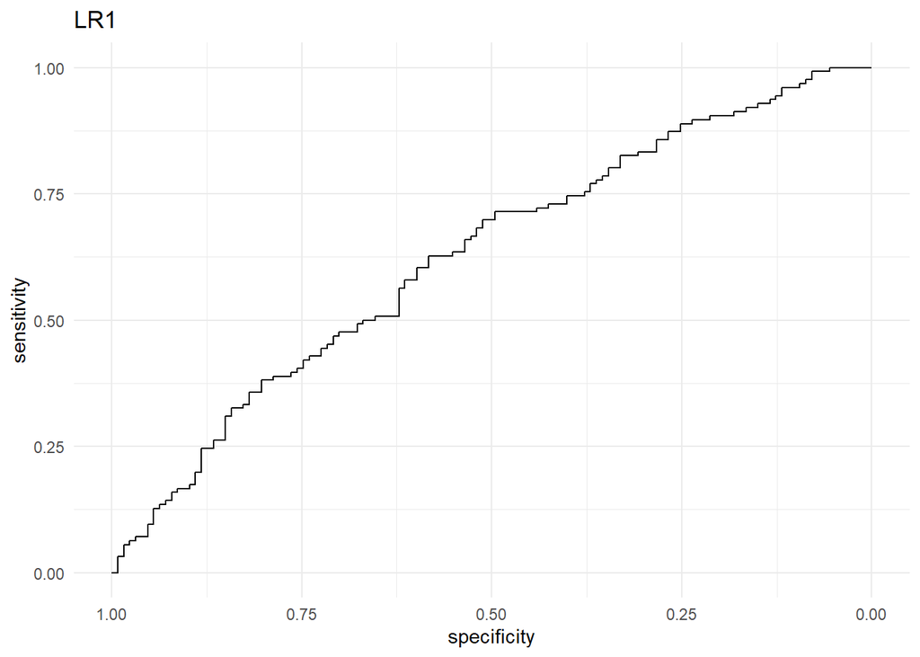

```r
roc_lr1 <- roc(treatment$response, lr1_prob)
roc_lr2 <- roc(treatment$response, lr2_prob)
ggroc(roc_lr1) + labs(title = "LR1") + theme_minimal()
```

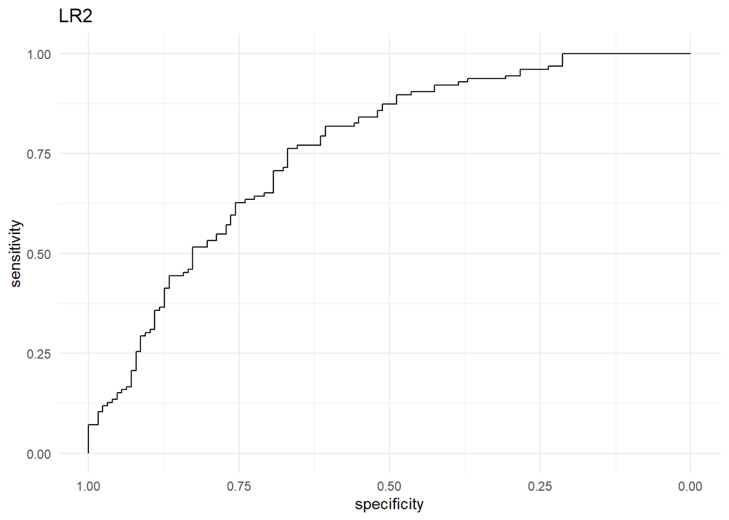

```r
ggroc(roc_lr2) + labs(title = "LR2") + theme_minimal()
```

### Exercise 7

The AUC of the first LR model is 0.6253.  
The AUC of the second LR model is 0.7588.

The AUC measures the area under the ROC. In the previous exercise we have seen that the ROC of `LR1` is closer to the line $y=x$. Therefore, the AUC is less than the AUC of `LR2`.  
The minimum AUC value is 0.5, while the “perfect” AUC value equals 1. In that “perfect” case, the ROC will almost look like a square.

```r
roc_lr1
```

```
##
## Call:
## roc.default(response = treatment$response, predictor = lr1_prob)
##
## Data: lr1_prob in 127 controls (treatment$response 0) < 126 cases (treatment$response 1).
## Area under the curve: 0.6253
```

```r
roc_lr2
```

```
##
## Call:
## roc.default(response = treatment$response, predictor = lr2_prob)
##
## Data: lr2_prob in 127 controls (treatment$response 0) < 126 cases (treatment$response 1).
## Area under the curve: 0.7588
```

### Exercise 8

From the density plots, we can see a clear distinction in specie for both petal width and length. Clearly, the setosa has lower length and width.  
A distinction can also be made by the length of the sepal. The width of the sepal is less discriminative than the other three observations.

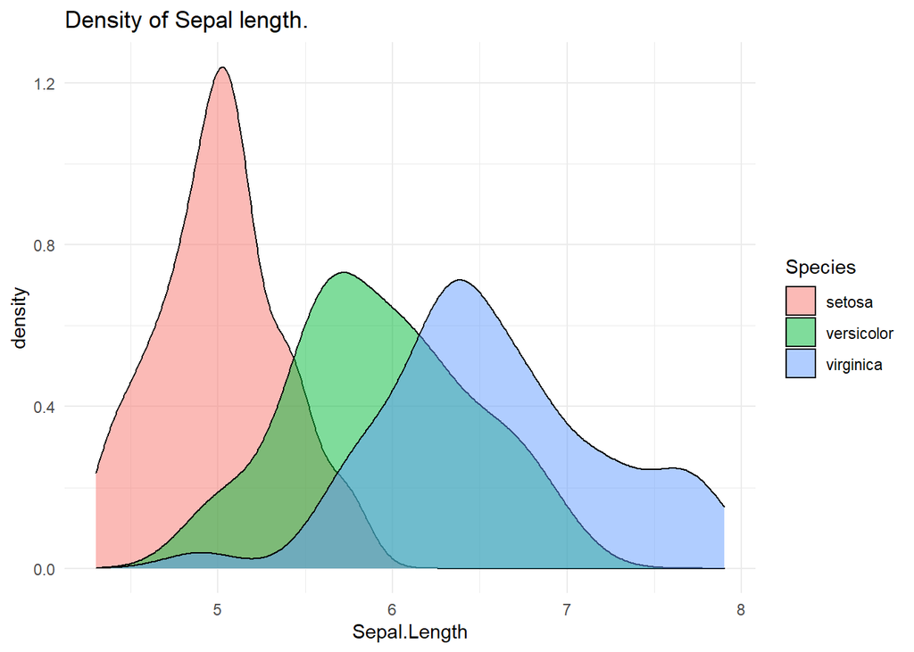

```r
iris %>% ggplot(aes(x = Sepal.Length, fill = Species)) +
  geom_density(alpha = 0.5) +
  labs(title = "Density of Sepal length.") +
  theme_minimal()
```

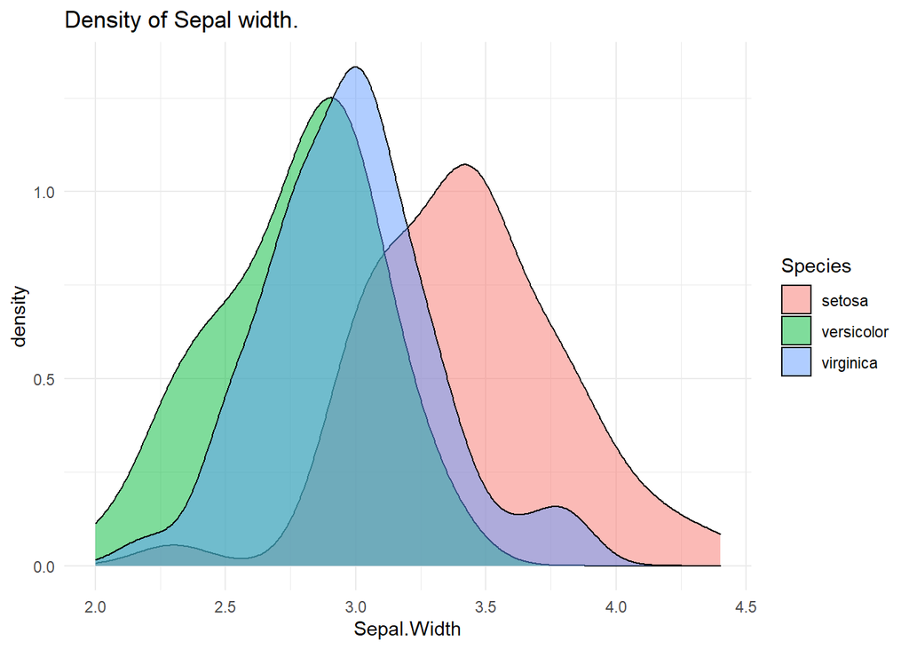

```r
iris %>% ggplot(aes(x = Sepal.Width, fill = Species)) +
  geom_density(alpha = 0.5) +
  labs(title = "Density of Sepal width.") +
  theme_minimal()
```

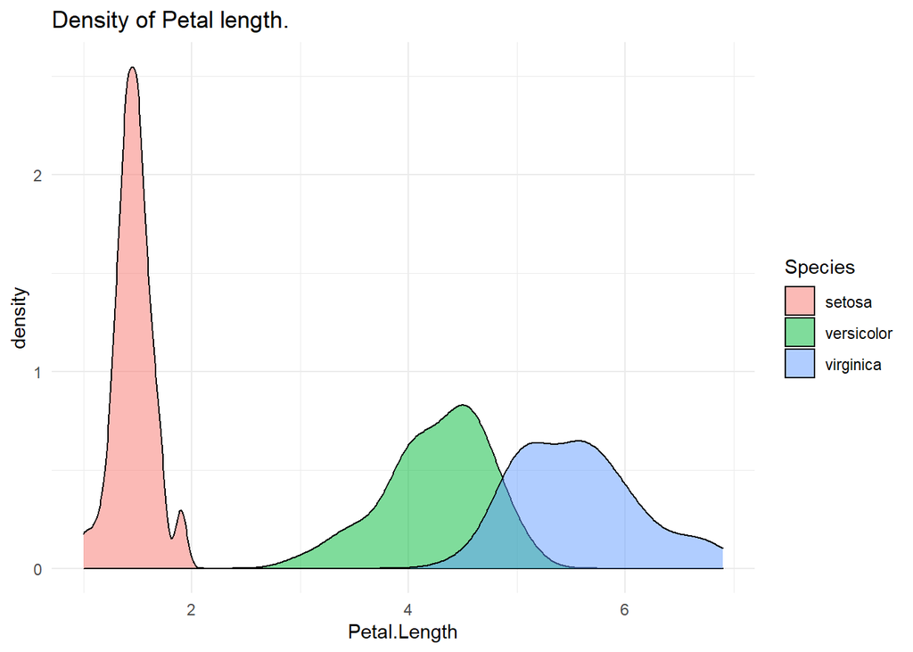

```r
iris %>% ggplot(aes(x = Petal.Length, fill = Species)) +
  geom_density(alpha = 0.5) +
  labs(title = "Density of Petal length.") +
  theme_minimal()
```

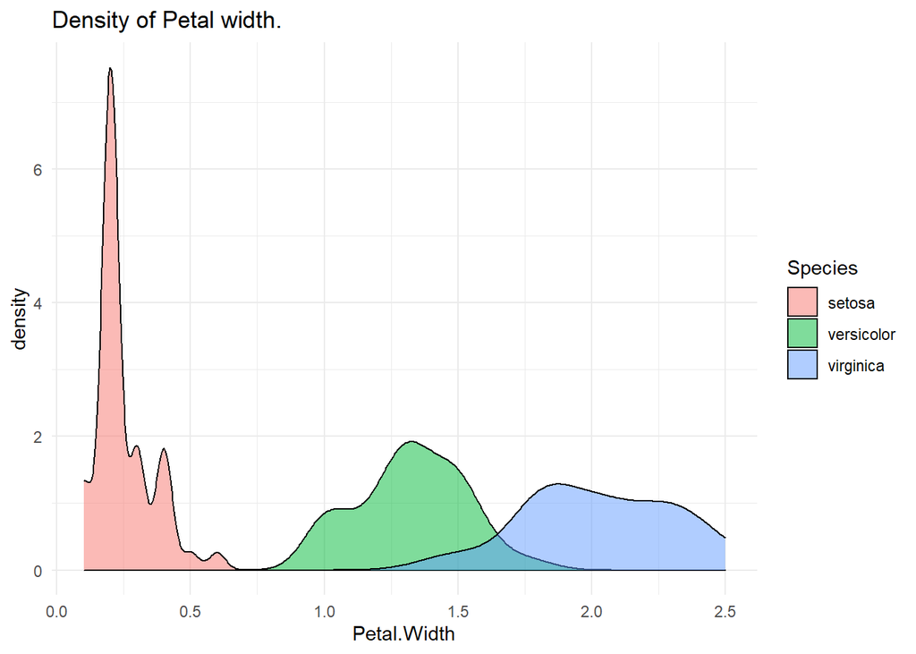

```r
iris %>% ggplot(aes(x = Petal.Width, fill = Species)) +
  geom_density(alpha = 0.5) +
  labs(title = "Density of Petal width.") +
  theme_minimal()
```

The last statement can be relaxed somewhat when looking at the summary of the variables. Here, we can see that the means of `setosa` differs from the means of the other species.

```r
iris %>% group_by(Species) %>% summarise_at(vars(Sepal.Length, Sepal.Width, Petal.Length, Petal.Width), list(name = mean))
```

| Species | Sepal.Length_name | Sepal.Width_name | Petal.Length_name | Petal.Width_name |
| --- | --- | --- | --- | --- |
| setosa | 5.006 | 3.428 | 1.462 | 0.246 |
| versicolor | 5.936 | 2.770 | 4.260 | 1.326 |
| virginica | 6.588 | 2.974 | 5.552 | 2.026 |

Lastly, it may be interesting to see if width and length are correlated. From the plots below, it looks like that width and length are uncorrelated for the sepal, but are correlated for the petal.

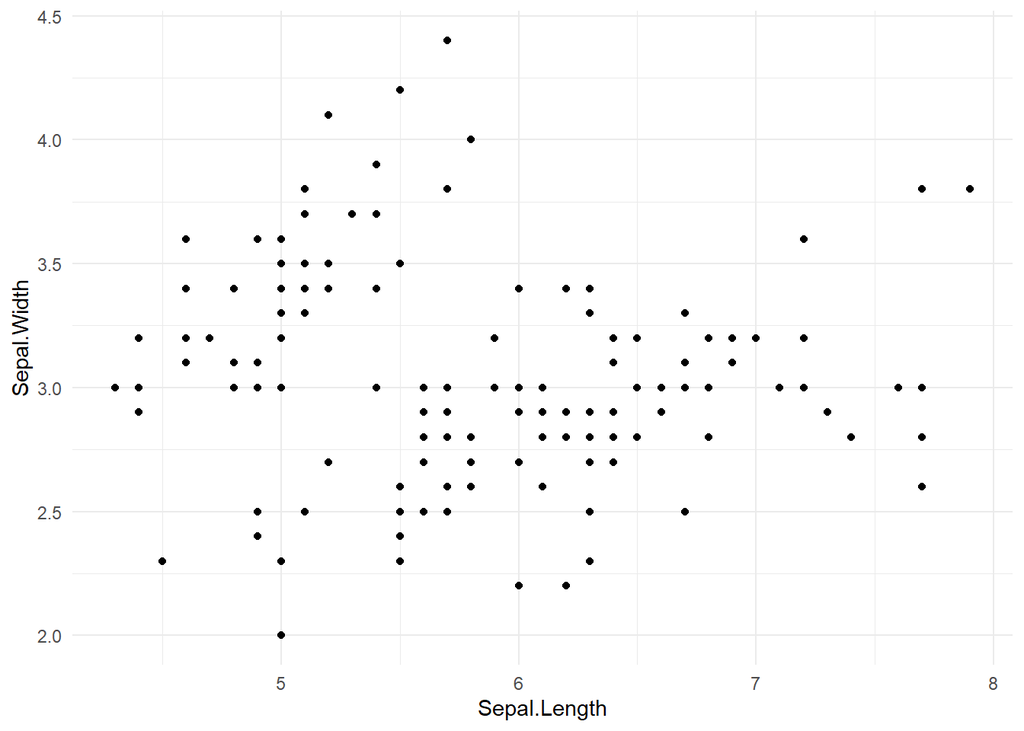

```r
iris %>% ggplot(aes(x =  Sepal.Length, y = Sepal.Width)) +
  geom_point() +
  theme_minimal()
```

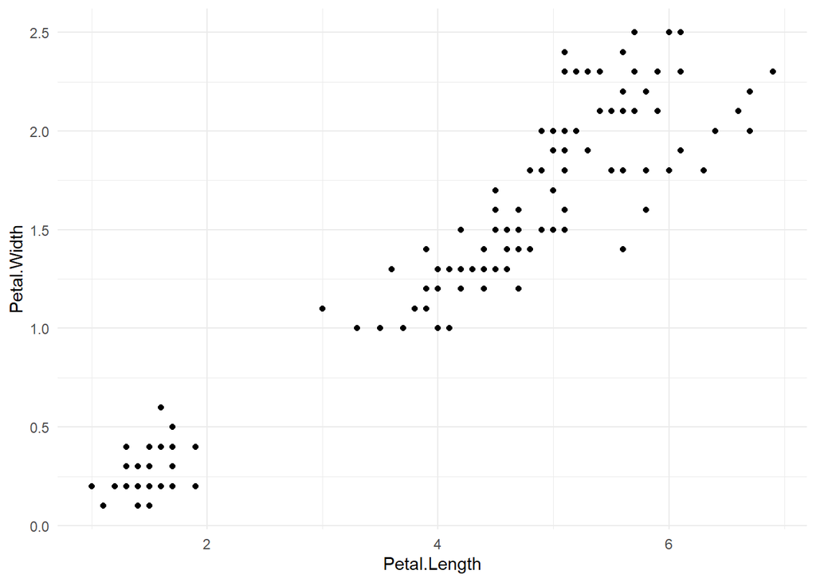

```r
iris %>% ggplot(aes(x = Petal.Length, y = Petal.Width)) +
  geom_point() +
  theme_minimal()
```